# Semesterbegleitende Abgabe SoSe2026

# Statistik im Bachelor Wirtschaftsinformatik

Dozent_innen: Martin Spott, Michael Heimann, Anja Hirsch  
Stand: 25.05.2026

**Gruppe:**

[Gruppe_Z1G1_H]

**Autor_innen:**

[ Alnabulsi, Mohamad Anas ]  
[ Habachia, Mohamad ]  
[ Orabe, Abdalkarem ]  
[ Ibrahim, Hassan ]

## Einleitung

In diesem Semester beschäftigen wir uns mit Kraftstoffpreisen in Berlin. Dazu benutzen wir Daten von der Organisation Tankerkönig [1], die jede Preisänderung angeschlossener Tankstellenbetreiber_innen mit Zeitstempel protokolliert. In der Datei *tankerkoenigSoSe2026.csv* finden Sie den Ausschnitt der Daten, den Sie für die Aufgaben benutzen sollen. Dabei haben wir für jede Tankstelle und jede Stunde den Median der von Tankerkönig registrierten Preisänderungen der Kraftstoffe Diesel und E10 ermittelt.

### Regeln

Arbeiten Sie in Ihrer Moodlegruppe von bis zu vier Studierenden, die alle in derselben Übungsgruppe sein und die eine zu wählende Abgabe auch in den zugehörigen Übungen vorstellen müssen (Terminkalender folgt). Jede/r von Ihnen hat in Moodle nur Zugriff auf die Gruppeneinteilung Ihrer in LSF festgelegten Übungsgruppe, wo Sie sich in einer Gruppe eintragen müssen, um Punkte zu bekommen.

Bearbeiten Sie die Aufgaben fortlaufend in diesem RMarkdown-Dokument und geben es bei jeder Teilabgabe komplett als RMarkdown- und als mit Knit übersetztes HTML-Dokument ab. Stellen Sie sicher, dass das RMarkdown-Dokument auch für uns lauffähig ist. Gehen Sie dazu davon aus, dass sich auf unseren Rechnern die Daten im selben Verzeichnis befinden werden wie Ihr RMarkdown-Dokument.

Benutzen Sie nur Verfahren und Techniken, die wir in der Vorlesung besprochen haben. Sie können aber gerne komplexere Visualisierungen einsetzen, wenn dies sinnvoll erscheint.

Erklären Sie kurz Ihr Vorgehen vor jedem Codeabschnitt und interpretieren die Ergebnisse danach. Schreiben Sie Erklärungen/Interpretationen in Textform zwischen die Codeblöcke, nicht als Kommentare in die Codeblöcke. Sie können den Code aber gerne zusätzlich knapp kommentieren.

Für jede weitere Woche bekommen Sie eine Aufgabenstellung in RMarkdown, die Sie bitte in diesem Dokument fortlaufend anhängen und dort bearbeiten. Geben Sie immer das gesamte Dokument einschließlich der vorangehenden Aufgaben ab, da die Aufgaben teilweise aufeinander aufbauen und Sie vorangehende Lösungen später benötigen.

## Woche 1 – 05.05.2026

Beschreiben Sie zwischen den Codeblöcken in Textform, was Sie warum tun und was Sie herausfinden.

**a. Importieren Sie die Daten.**

```r
# WICHTIG: Die Datei tankerkoenigSoSe2026.csv muss im selben Ordner liegen!
tankerkoenig <- read.csv("tankerkoenigSoSe2026.csv")

# Einen ersten Überblick über die Datenstruktur verschaffen
str(tankerkoenig)
```

```
## 'data.frame':    441078 obs. of  13 variables:
##  $ X            : int  0 1 2 3 4 5 6 7 8 9 ...
##  $ id           : chr  "005056ba-7cb6-1ed2-bceb-6dbab19bed20" "005056ba-7cb6-1ed2-bceb-6dbab19bed20" "005056ba-7cb6-1ed2-bceb-6dbab19bed20" "005056ba-7cb6-1ed2-bceb-6dbab19bed20" ...
##  $ date         : chr  "2025-02-01" "2025-02-01" "2025-02-01" "2025-02-01" ...
##  $ time         : chr  "08:30" "09:30" "10:30" "11:30" ...
##  $ name         : chr  "star Tankstelle" "star Tankstelle" "star Tankstelle" "star Tankstelle" ...
##  $ brand        : chr  "STAR" "STAR" "STAR" "STAR" ...
##  $ street       : chr  "Steglitzer Damm 77" "Steglitzer Damm 77" "Steglitzer Damm 77" "Steglitzer Damm 77" ...
##  $ house_number : chr  NA NA NA NA ...
##  $ post_code    : int  12169 12169 12169 12169 12169 12169 12169 12169 12169 12169 ...
##  $ opening_time : chr  "07:00" "07:00" "07:00" "07:00" ...
##  $ closing_time : chr  "23:00" "23:00" "23:00" "23:00" ...
##  $ e10_median   : int  1769 1799 1779 1699 1689 1699 1749 1719 1704 1694 ...
##  $ diesel_median: int  1709 1719 1669 1609 1629 1619 1669 1644 1634 1634 ...
```

**b. Beschreiben Sie die Daten. Was sind die Merkmale, was die Merkmalsträger?**

Merkmalsträger (Untersuchungseinheit): Ein einzelner Merkmalsträger ist hier eine spezifische Tankstelle in einer ganz bestimmten Stunde. Jeder Zeile im Datensatz (jede Beobachtung) entspricht genau einer solchen Kombination aus Tankstelle und Stunde.

Merkmale (Variablen): Die Merkmale sind die für diese Träger erfassten Eigenschaften. Dazu gehören laut Einleitung die Tankstelle (z.B. ID), die Zeit (Stunde), die Marke der Tankstelle (`brand`) sowie der jeweilige Median-Preis für Diesel und E10.

**c. Geben Sie für alle Merkmale an, ob sie qualitativ/quantitativ, diskret/stetig und auf welchen Skalen sie definiert sind.**

Aus der Beschreibung des Datensatzes lassen sich folgende Einstufungen ableiten: 1. Tankstellen-Identifikator: Qualitativ, nominalskaliert. 2. Marke (`brand`): Qualitativ, nominalskaliert (Kategorien ohne natürliche Rangfolge). 3. Stunde (Zeitstempel): Quantitativ, intervallskaliert (oder verhältnisskaliert, wenn als Dauer seit einem Nullpunkt gemessen). Wird hier als diskret behandelt, da es sich um volle Stunden handelt. 4. Preise (Diesel & E10): Quantitativ, stetig, verhältnisskaliert (sie können jeden beliebigen Zwischenwert annehmen und haben einen absoluten Nullpunkt bei 0 Euro).

**d. Berechnen Sie für das Merkmal `brand` (Marke) die Tabellen mit absoluter und relativer Häufigkeit.**

Wir verwenden die Funktionen `table()` für die absoluten Zahlen und `prop.table()` für die relativen Anteile. Um das Ergebnis lesbar darzustellen, fassen wir es in einem Data Frame zusammen.

```r
# Absolute Häufigkeiten berechnen
abs_freq_brand <- table(tankerkoenig$brand)

# Relative Häufigkeiten berechnen
rel_freq_brand <- prop.table(abs_freq_brand)

# Tabelle zusammenbauen und runden
brand_tabelle <- data.frame(
  Marke = names(abs_freq_brand),
  Absolute_Haeufigkeit = as.numeric(abs_freq_brand),
  Relative_Haeufigkeit = round(as.numeric(rel_freq_brand), 4)
)

# Ausgabe der fertigen Tabelle
brand_tabelle
```

```
##           Marke Absolute_Haeufigkeit Relative_Haeufigkeit
## 1      AGIP ENI                28729               0.0651
## 2          ARAL                54508               0.1236
## 3          ESSO                28937               0.0656
## 4           HEM                41605               0.0943
## 5           JET                34444               0.0781
## 6         Shell                98465               0.2232
## 7        Sprint                34005               0.0771
## 8          STAR                53461               0.1212
## 9 TotalEnergies                66924               0.1517
```

**e. Stellen Sie die Tabelle absoluter Häufigkeit von `brand` als Balkendiagramm dar. Beschriften Sie alle Axen und geben dem Diagramm eine Überschrift.**

Wir nutzen die Funktion `barplot()`. Mit dem Argument `las = 2` stellen wir sicher, dass die Namen der Marken senkrecht geschrieben werden, falls es viele Marken gibt und der Platz sonst nicht reicht.

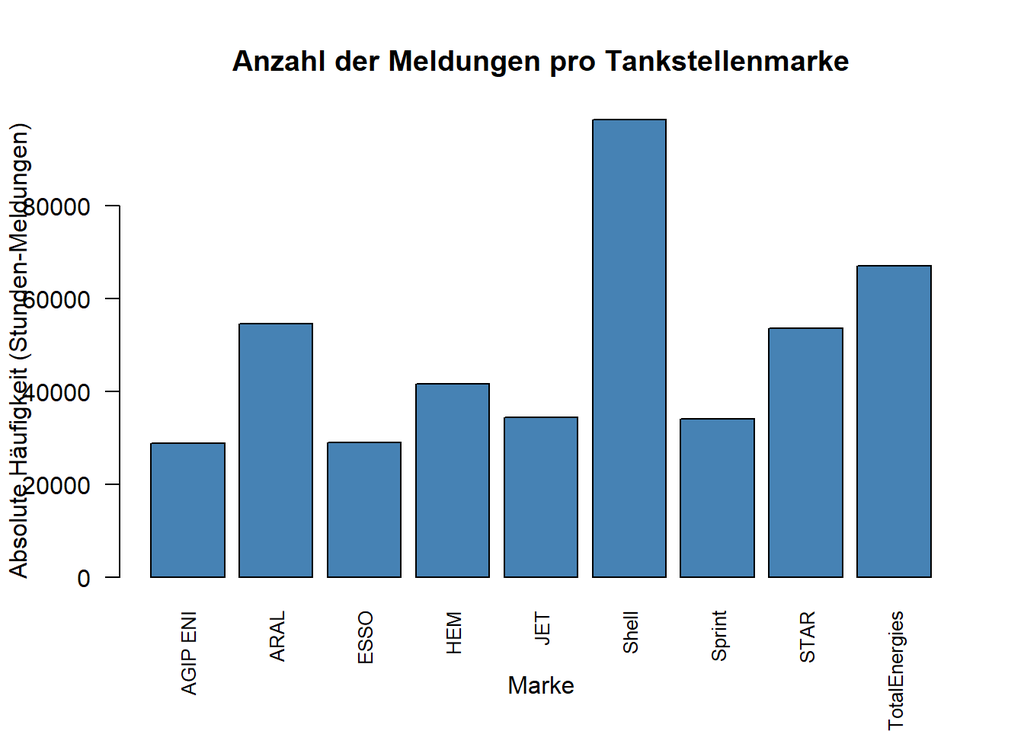

```r
# Balkendiagramm zeichnen
barplot(abs_freq_brand,
        main = "Anzahl der Meldungen pro Tankstellenmarke",
        xlab = "Marke",
        ylab = "Absolute Häufigkeit (Stunden-Meldungen)",
        col = "steelblue",
        las = 2,           # Dreht die Beschriftung der x-Achse um 90 Grad
        cex.names = 0.8)   # Macht die Schrift der Achse etwas kleiner
```

**f. Was bedeuten die absoluten Häufigkeiten im Kontext unserer Daten? Warum gibt es Unterschiede zwischen den Werten der verschiedenen Marken?**

Die absoluten Häufigkeiten geben nicht nur die reine Anzahl der Tankstellen pro Marke an. Da unsere Merkmalsträger eine Kombination aus “Tankstelle” und “Stunde” sind, zeigt die absolute Häufigkeit, wie viele stündliche Preismeldungen insgesamt von einer bestimmten Marke im Datensatz vorliegen.

**Unterschiede zwischen den Marken** kommen hauptsächlich durch zwei Dinge zustande: 1. Unterschiedliche Marktanteile: Große Anbieter (wie Aral oder Shell) haben deutlich mehr Tankstellen in Berlin als kleinere Anbieter. Mehr Tankstellen produzieren pro Stunde auch mehr Datensätze.

2. Öffnungszeiten und Verfügbarkeit: Wenn Tankstellen nachts geschlossen sind oder ihre Preise nicht durchgehend übermitteln, fehlen für diese Stunden die Meldungen. Marken mit vielen 24/7-Tankstellen generieren also verhältnismäßig mehr Datensätze.

## Woche 2 – 12.05.2026

**a. Bestimmen Sie, wie viele Werte bei jedem Merkmal im Datensatz fehlen (NA). Finden Sie mit etwas Detektivarbeit heraus, welche Eigenschaft die Datensätze mit den fehlenden Werten haben und wie man die fehlenden mit sinnvollen Werten ersetzen kann. Das Ersetzen müssen Sie nur erklären, nicht implementieren.**

Zuerst zählen wir für jedes Merkmal, wie viele Einträge fehlen. Dafür verwenden wir `is.na()` für jede Spalte und summieren die TRUE-Werte.

```r
fehlende_werte <- colSums(is.na(tankerkoenig))

data.frame(
  Merkmal = names(fehlende_werte),
  Fehlende_Werte = as.numeric(fehlende_werte)
)
```

```
##          Merkmal Fehlende_Werte
## 1              X              0
## 2             id              0
## 3           date              0
## 4           time              0
## 5           name              0
## 6          brand              0
## 7         street              0
## 8   house_number          75148
## 9      post_code              0
## 10  opening_time              0
## 11  closing_time              0
## 12    e10_median            811
## 13 diesel_median              0
```

Die fehlenden Werte treten nur bei `house_number` und `e10_median` auf. Um die Ursache genauer zu verstehen, betrachten wir die betroffenen Tankstellen.

```r
# Tankstellen mit fehlender Hausnummer
unique(tankerkoenig[is.na(tankerkoenig$house_number),
                    c("id", "name", "brand", "street", "post_code")])
```

```
##                                         id
## 1     005056ba-7cb6-1ed2-bceb-6dbab19bed20
## 5639  005056ba-7cb6-1ed2-bceb-6e844f9e6d20
## 10795 005056ba-7cb6-1ed2-bceb-8e5fec1a0d35
## 17348 005056ba-7cb6-1ed2-bceb-8f11d216cd35
## 22894 005056ba-7cb6-1ed2-bceb-aba199748d43
## 29403 005056ba-7cb6-1ed5-a6a1-930ae49a5411
## 35730 005056ba-7cb6-1ee5-a980-090160c05099
## 41428 005056ba-7cb6-1ee5-b187-bc79c0a8d9ec
## 48010 005056ba-7cb6-1ee5-b791-639597361b11
## 53462 01abf2e9-84e2-4328-936f-9958c7c733a8
## 59157 0591a60a-a167-4cc5-a200-c21d4a1e698e
## 64093 1b25d42b-65e8-4724-a801-6a921b273aa7
## 69507 1c002618-6ca6-4faf-9752-688a83b5e818
##                                           name brand
```

[output cut: 27 more lines]

```r
# Tankstelle(n) mit fehlendem E10-Preis
unique(tankerkoenig[is.na(tankerkoenig$e10_median),
                    c("id", "name", "brand", "street",
                      "house_number", "post_code")])
```

```
##                                          id                          name brand
## 374449 defadb89-ee11-459a-9ce5-416df31ee2e8 Shell Berlin Heerstr. 326-328 Shell
##          street house_number post_code
## 374449 Heerstr.      326-328     13593
```

```r
# Zeitraum der fehlenden E10-Werte
range(tankerkoenig$date[is.na(tankerkoenig$e10_median)])
```

```
## [1] "2025-08-07" "2025-09-30"
```

Bei `house_number` sieht man, dass die Hausnummer nicht wirklich unbekannt ist. Sie steht bei diesen Datensätzen bereits im Merkmal `street`, zum Beispiel in Einträgen wie `Steglitzer Damm 77`, `Königin-Luise-Straße 22a` oder `Prenzlauer Promenade 72-73`. Sinnvoll wäre deshalb, die Hausnummer aus dem Ende des Straßennamens zu übernehmen und das Merkmal `street` danach auf den reinen Straßennamen zu kürzen.

Die fehlenden Werte bei `e10_median` gehören alle zu einer einzelnen Shell-Tankstelle: `Shell Berlin Heerstr. 326-328`. Der Zeitraum reicht vom 07.08.2025 bis zum 30.09.2025. Für diese Zeilen ist `diesel_median` vorhanden, nur der E10-Wert fehlt. Sinnvoll wäre hier eine Schätzung aus den vorhandenen Daten derselben Tankstelle, zum Beispiel indem man für diese Tankstelle die typische Differenz `e10_median - diesel_median` in den übrigen Zeitpunkten berechnet und diese Differenz auf die vorhandenen Dieselpreise addiert. Noch genauer wäre eine Differenz nach Uhrzeit, weil Kraftstoffpreise im Tagesverlauf schwanken.

**b. Erstellen Sie Histogramme für die Merkmale `e10_median` und `diesel_median` und zeichnen jeweils das arithmetische Mittel und den Median ein.**

Für die Histogramme entfernen wir fehlende E10-Werte mit `na.omit()`. Die Preise sind im Datensatz als ganze Zahlen gespeichert, zum Beispiel 1769 für 1,769 Euro. Für die Lagewerte spielt diese Skalierung keine Rolle, die Achsenbeschriftung weist aber auf diese Einheit hin.

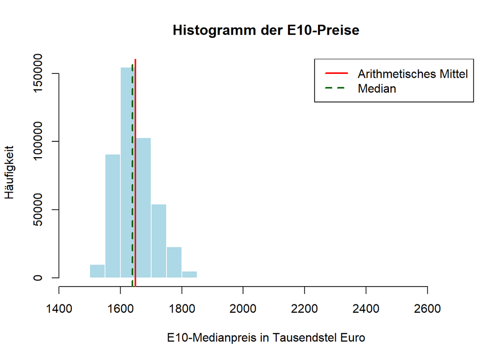

```r
e10_werte <- na.omit(tankerkoenig$e10_median)
e10_mittel <- mean(e10_werte)
e10_median <- median(e10_werte)

hist(e10_werte,
     main = "Histogramm der E10-Preise",
     xlab = "E10-Medianpreis in Tausendstel Euro",
     ylab = "Häufigkeit",
     col = "lightblue",
     border = "white")

abline(v = e10_mittel, col = "red", lwd = 2)
abline(v = e10_median, col = "darkgreen", lwd = 2, lty = 2)
legend("topright",
       legend = c("Arithmetisches Mittel", "Median"),
       col = c("red", "darkgreen"),
       lwd = 2,
       lty = c(1, 2))
```

Beim E10-Preis liegt das arithmetische Mittel etwas oberhalb des Medians. Das deutet darauf hin, dass einige höhere Preise den Durchschnitt nach oben ziehen.

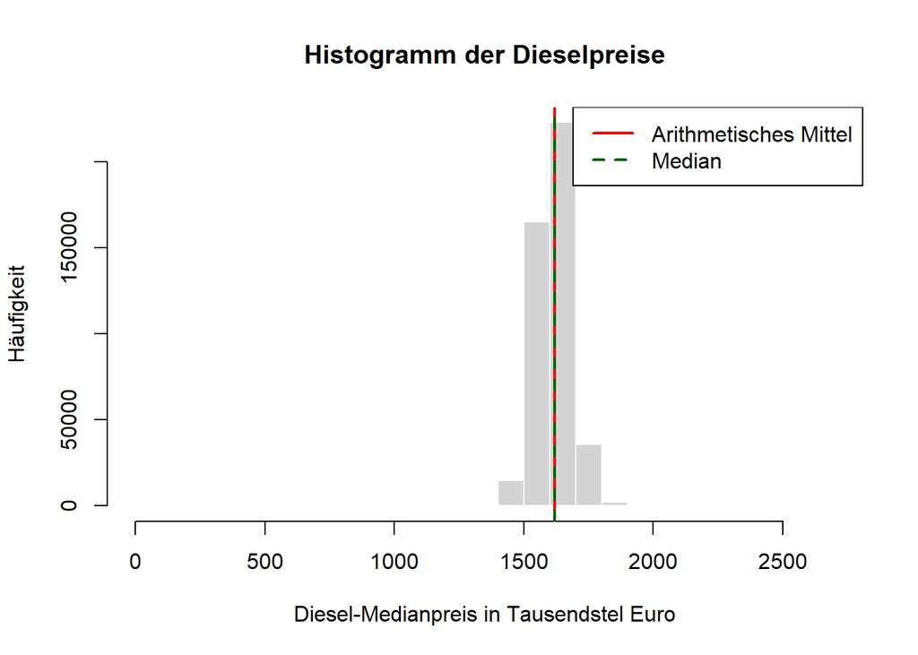

```r
diesel_werte <- tankerkoenig$diesel_median
diesel_mittel <- mean(diesel_werte)
diesel_median_wert <- median(diesel_werte)

hist(diesel_werte,
     main = "Histogramm der Dieselpreise",
     xlab = "Diesel-Medianpreis in Tausendstel Euro",
     ylab = "Häufigkeit",
     col = "lightgray",
     border = "white")

abline(v = diesel_mittel, col = "red", lwd = 2)
abline(v = diesel_median_wert, col = "darkgreen", lwd = 2, lty = 2)
legend("topright",
       legend = c("Arithmetisches Mittel", "Median"),
       col = c("red", "darkgreen"),
       lwd = 2,
       lty = c(1, 2))
```

Beim Dieselpreis liegen arithmetisches Mittel und Median sehr nah beieinander. Die Verteilung ist dadurch im Zentrum ungefähr ausgeglichen.

**c. Finden Sie heraus, wie man zwei Histogramme zum besseren Vergleich in einem Diagramm überlagern kann. Dazu können Sie auch Bibliotheken wie ggplot2 und plotly betrachten.**

Zwei Histogramme kann man überlagern, indem man für beide Merkmale dieselben Klassengrenzen verwendet und halbtransparente Farben setzt. Dadurch bleiben die Bereiche sichtbar, in denen sich die Verteilungen überschneiden.

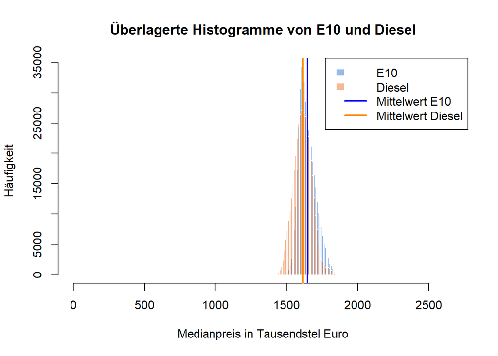

```r
gemeinsame_grenzen <- seq(
  floor(min(c(e10_werte, diesel_werte), na.rm = TRUE) / 10) * 10,
  ceiling(max(c(e10_werte, diesel_werte), na.rm = TRUE) / 10) * 10,
  by = 10
)

hist(e10_werte,
     breaks = gemeinsame_grenzen,
     col = rgb(0.1, 0.4, 0.8, 0.45),
     border = "white",
     main = "Überlagerte Histogramme von E10 und Diesel",
     xlab = "Medianpreis in Tausendstel Euro",
     ylab = "Häufigkeit")

hist(diesel_werte,
     breaks = gemeinsame_grenzen,
     col = rgb(0.9, 0.4, 0.1, 0.45),
     border = "white",
     add = TRUE)

abline(v = e10_mittel, col = "blue", lwd = 2)
abline(v = diesel_mittel, col = "darkorange", lwd = 2)

legend("topright",
       legend = c("E10", "Diesel", "Mittelwert E10", "Mittelwert Diesel"),
       fill = c(rgb(0.1, 0.4, 0.8, 0.45),
                rgb(0.9, 0.4, 0.1, 0.45),
                NA,
                NA),
       border = c("white", "white", NA, NA),
       col = c(NA, NA, "blue", "darkorange"),
       lwd = c(NA, NA, 2, 2))
```

Im überlagerten Histogramm erkennt man, dass die E10-Preise insgesamt etwas höher liegen als die Dieselpreise. Die beiden Verteilungen überschneiden sich aber stark, weil beide Kraftstoffarten ähnlichen Markt- und Tagespreisschwankungen unterliegen.

## Woche 3 – 19.05.2026

**a. Bestimmen Sie Fünf- oder Sechs-Punkte-Zusammenfassungen der Merkmale `e10_median` und `diesel_median` und erstellen zugehörige Boxplots mit Ausreißererkennung. Beschreiben Sie anhand dessen die Unterschiede zwischen den Werteverteilungen der Merkmale.**

Zuerst bestimmen wir für beide Kraftstoffarten die Sechs-Punkte-Zusammenfassung mit Minimum, erstem Quartil, Median, arithmetischem Mittel, drittem Quartil und Maximum. Fehlende Werte bei `e10_median` werden dabei entfernt.

```r
e10_werte <- na.omit(tankerkoenig$e10_median)
diesel_werte <- na.omit(tankerkoenig$diesel_median)

zusammenfassung_preise <- data.frame(
  Merkmal = c("E10", "Diesel"),
  Minimum = c(min(e10_werte), min(diesel_werte)),
  Q1 = c(quantile(e10_werte, 0.25), quantile(diesel_werte, 0.25)),
  Median = c(median(e10_werte), median(diesel_werte)),
  Mittelwert = c(mean(e10_werte), mean(diesel_werte)),
  Q3 = c(quantile(e10_werte, 0.75), quantile(diesel_werte, 0.75)),
  Maximum = c(max(e10_werte), max(diesel_werte))
)

zusammenfassung_preise
```

```
##   Merkmal Minimum   Q1 Median Mittelwert   Q3 Maximum
## 1     E10    1484 1609   1639   1649.274 1689    2669
## 2  Diesel       0 1574   1619   1618.157 1659    2619
```

Für die Boxplots verwenden wir die übliche 1,5-IQR-Regel. Werte außerhalb der Antennen werden im Boxplot als Ausreißer dargestellt.

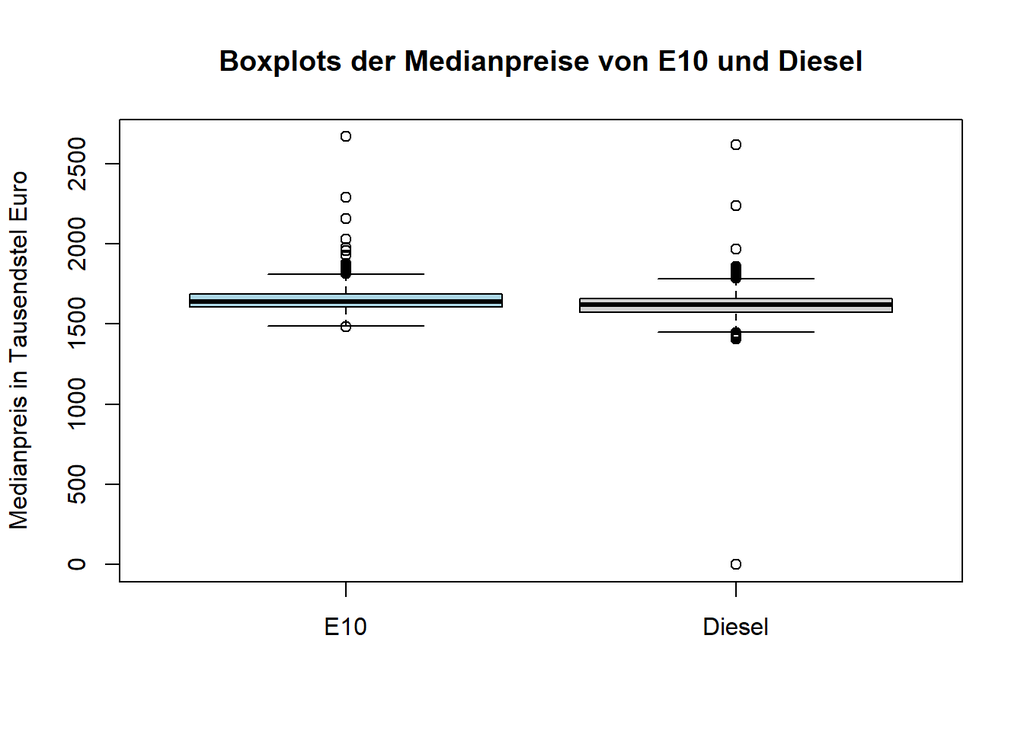

```r
boxplot(e10_werte, diesel_werte,
        names = c("E10", "Diesel"),
        main = "Boxplots der Medianpreise von E10 und Diesel",
        ylab = "Medianpreis in Tausendstel Euro",
        col = c("lightblue", "lightgray"))
```

Die mittleren 50 % der E10-Werte liegen zwischen 1609 und 1689, bei Diesel zwischen 1574 und 1659. E10 liegt damit im Zentrum der Verteilung etwas höher als Diesel. Der Median beträgt bei E10 1639 und bei Diesel 1619. Beide Verteilungen haben Ausreißer nach unten und oben. Besonders auffällig ist bei Diesel das Minimum 0, denn ein Dieselpreis von 0 ist fachlich kein realistischer Kraftstoffpreis. Bei E10 ist das Maximum 2669 ebenfalls extrem hoch gegenüber dem normalen Wertebereich.

**b. Extrahieren Sie die Ausreißer von `e10_median` und `diesel_median`. Finden Sie mit Detektivarbeit heraus, ob es ein Muster für die Ausreißer gibt, z.B. wann sie wo auftreten, und ob die Ausreißer echte oder falsche Werte sind.**

Wir berechnen zunächst die unteren und oberen Ausreißergrenzen nach der 1,5-IQR-Regel und filtern anschließend alle betroffenen Datensätze heraus.

```r
ausreisser_grenzen <- function(x) {
  x <- x[!is.na(x)]
  q1 <- quantile(x, 0.25)
  q3 <- quantile(x, 0.75)
  iqr <- IQR(x)
  c(unten = q1 - 1.5 * iqr,
    oben = q3 + 1.5 * iqr)
}

grenzen_e10 <- ausreisser_grenzen(tankerkoenig$e10_median)
grenzen_diesel <- ausreisser_grenzen(tankerkoenig$diesel_median)

ausreisser_e10 <- tankerkoenig[
  !is.na(tankerkoenig$e10_median) &
    (tankerkoenig$e10_median < grenzen_e10["unten"] |
       tankerkoenig$e10_median > grenzen_e10["oben"]),
]

ausreisser_diesel <- tankerkoenig[
  !is.na(tankerkoenig$diesel_median) &
    (tankerkoenig$diesel_median < grenzen_diesel["unten"] |
       tankerkoenig$diesel_median > grenzen_diesel["oben"]),
]

data.frame(
  Merkmal = c("E10", "Diesel"),
  Untere_Grenze = c(grenzen_e10["unten"], grenzen_diesel["unten"]),
  Obere_Grenze = c(grenzen_e10["oben"], grenzen_diesel["oben"]),
  Anzahl_Ausreisser = c(nrow(ausreisser_e10), nrow(ausreisser_diesel))
)
```

[output not shown]

```r
# Monate mit den meisten Ausreißern
sort(table(substr(ausreisser_e10$date, 1, 7)), decreasing = TRUE)[1:6]
```

```
## [1] NA NA NA NA NA NA
```

```r
sort(table(substr(ausreisser_diesel$date, 1, 7)), decreasing = TRUE)[1:6]
```

```
## [1] NA NA NA NA NA NA
```

```r
# Uhrzeiten mit den meisten Ausreißern
sort(table(ausreisser_e10$time), decreasing = TRUE)[1:8]
```

```
## [1] NA NA NA NA NA NA NA NA
```

```r
sort(table(ausreisser_diesel$time), decreasing = TRUE)[1:8]
```

```
## [1] NA NA NA NA NA NA NA NA
```

```r
# Marken mit den meisten Ausreißern
sort(table(ausreisser_e10$brand), decreasing = TRUE)[1:8]
```

```
## [1] NA NA NA NA NA NA NA NA
```

```r
sort(table(ausreisser_diesel$brand), decreasing = TRUE)[1:8]
```

```
## [1] NA NA NA NA NA NA NA NA
```

```r
auswahl_spalten <- c("date", "time", "name", "brand", "street",
                     "house_number", "post_code", "e10_median",
                     "diesel_median")

# Größte E10-Ausreißer
head(ausreisser_e10[order(-ausreisser_e10$e10_median),
                    auswahl_spalten], 12)
```

[output not shown]

```r
# Kleinste E10-Ausreißer
head(ausreisser_e10[order(ausreisser_e10$e10_median),
                    auswahl_spalten], 8)
```

```
##      date time name brand street house_number post_code e10_median
## NA   <NA> <NA> <NA>  <NA>   <NA>         <NA>        NA         NA
## NA.1 <NA> <NA> <NA>  <NA>   <NA>         <NA>        NA         NA
## NA.2 <NA> <NA> <NA>  <NA>   <NA>         <NA>        NA         NA
## NA.3 <NA> <NA> <NA>  <NA>   <NA>         <NA>        NA         NA
## NA.4 <NA> <NA> <NA>  <NA>   <NA>         <NA>        NA         NA
## NA.5 <NA> <NA> <NA>  <NA>   <NA>         <NA>        NA         NA
## NA.6 <NA> <NA> <NA>  <NA>   <NA>         <NA>        NA         NA
## NA.7 <NA> <NA> <NA>  <NA>   <NA>         <NA>        NA         NA
##      diesel_median
## NA              NA
## NA.1            NA
## NA.2            NA
## NA.3            NA
## NA.4            NA
## NA.5            NA
## NA.6            NA
## NA.7            NA
```

```r
# Größte Diesel-Ausreißer
head(ausreisser_diesel[order(-ausreisser_diesel$diesel_median),
                       auswahl_spalten], 12)
```

[output not shown]

```r
# Kleinste Diesel-Ausreißer
head(ausreisser_diesel[order(ausreisser_diesel$diesel_median),
                       auswahl_spalten], 12)
```

[output not shown]

**c. Berechnen Sie die mittlere absolute Abweichung vom arithmetischen Mittel und die Standardabweichung von `e10_median` und `diesel_median` und vergleichen die Werte.**

Die mittlere absolute Abweichung berechnen wir hier als durchschnittlichen absoluten Abstand aller Werte vom arithmetischen Mittel. Die Standardabweichung misst ebenfalls Streuung, gewichtet große Abweichungen wegen des Quadrierens aber stärker.

```r
mittlere_absolute_abweichung <- function(x) {
  x <- x[!is.na(x)]
  mean(abs(x - mean(x)))
}

streuung_preise <- data.frame(
  Merkmal = c("E10", "Diesel"),
  Mittlere_absolute_Abweichung = c(
    mittlere_absolute_abweichung(tankerkoenig$e10_median),
    mittlere_absolute_abweichung(tankerkoenig$diesel_median)
  ),
  Standardabweichung = c(
    sd(tankerkoenig$e10_median, na.rm = TRUE),
    sd(tankerkoenig$diesel_median, na.rm = TRUE)
  )
)

streuung_preise
```

```
##   Merkmal Mittlere_absolute_Abweichung Standardabweichung
## 1     E10                     47.89162           59.45331
## 2  Diesel                     51.05878           64.31796
```

## Woche 4 – 26.05.2026

**a. Wochentag-Spalte und Boxplots nach Wochentag**

Um den Wochentag zu bestimmen, nutzen wir `format(as.Date(...), "%u")` statt `weekdays()`, weil letzteres je nach Systemsprache englische oder deutsche Namen liefert und das auf anderen Rechnern zu Fehlern führen kann. `%u` gibt immer eine Zahl zurück (1 = Montag, 7 = Sonntag), und wir weisen die deutschen Namen dann selbst zu. Danach machen wir die Spalte zu einem geordneten Faktor, damit die Boxplots von Montag bis Sonntag sortiert erscheinen.

```r
# Wochentag locale-unabhaengig ueber ISO-Nummer ableiten:
# %u liefert 1 (Montag) bis 7 (Sonntag) - unabhaengig von der Systemsprache
wt_nummer <- as.integer(format(as.Date(tankerkoenig$date), "%u"))

# Deutsche Bezeichnungen manuell zuweisen
wochentag_reihenfolge <- c("Montag", "Dienstag", "Mittwoch",
                            "Donnerstag", "Freitag", "Samstag", "Sonntag")
tankerkoenig$wochentag <- factor(wochentag_reihenfolge[wt_nummer],
                                  levels = wochentag_reihenfolge,
                                  ordered = TRUE)

# Ueberpruefung: erste Zeilen mit neuem Merkmal
head(tankerkoenig[, c("date", "wochentag", "e10_median", "diesel_median")])
```

```
##         date wochentag e10_median diesel_median
## 1 2025-02-01   Samstag       1769          1709
## 2 2025-02-01   Samstag       1799          1719
## 3 2025-02-01   Samstag       1779          1669
## 4 2025-02-01   Samstag       1699          1609
## 5 2025-02-01   Samstag       1689          1629
## 6 2025-02-01   Samstag       1699          1619
```

Die sieben Boxplots für E10 und Diesel zeichnen wir jeweils nebeneinander. Mit `par(mfrow = c(1,2))` kommen beide Plots in eine Zeile, `outline = FALSE` blendet Ausreißer aus, damit die Boxen selbst besser lesbar sind.

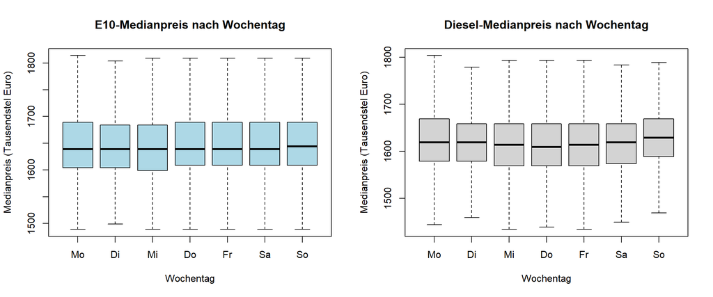

```r
# Kurzbezeichnungen für die x-Achse
wt_kurz <- c("Mo", "Di", "Mi", "Do", "Fr", "Sa", "So")

par(mfrow = c(1, 2))   # zwei Plots nebeneinander

boxplot(e10_median ~ wochentag, data = tankerkoenig,
        main = "E10-Medianpreis nach Wochentag",
        xlab = "Wochentag", ylab = "Medianpreis (Tausendstel Euro)",
        col = "lightblue", names = wt_kurz,
        outline = FALSE)   # Ausreißer ausblenden für bessere Übersicht

boxplot(diesel_median ~ wochentag, data = tankerkoenig,
        main = "Diesel-Medianpreis nach Wochentag",
        xlab = "Wochentag", ylab = "Medianpreis (Tausendstel Euro)",
        col = "lightgray", names = wt_kurz,
        outline = FALSE)
```

```r
par(mfrow = c(1, 1))
```

```r
# Absolute Preisunterschiede zwischen Wochentagen messen
wt_stats_e10 <- tapply(tankerkoenig$e10_median, tankerkoenig$wochentag, median, na.rm = TRUE)
wt_stats_diesel <- tapply(tankerkoenig$diesel_median, tankerkoenig$wochentag, median, na.rm = TRUE)

wt_vergleich <- data.frame(
  Wochentag = wochentag_reihenfolge,
  E10_Median = round(wt_stats_e10, 1),
  Diesel_Median = round(wt_stats_diesel, 1)
)
wt_vergleich$E10_Diff_zum_Mo   <- round(wt_vergleich$E10_Median - wt_vergleich$E10_Median[1], 1)
wt_vergleich$Diesel_Diff_zum_Mo <- round(wt_vergleich$Diesel_Median - wt_vergleich$Diesel_Median[1], 1)
wt_vergleich
```

```
##             Wochentag E10_Median Diesel_Median E10_Diff_zum_Mo
## Montag         Montag       1639          1619               0
## Dienstag     Dienstag       1639          1619               0
## Mittwoch     Mittwoch       1639          1614               0
## Donnerstag Donnerstag       1639          1609               0
## Freitag       Freitag       1639          1614               0
## Samstag       Samstag       1639          1619               0
## Sonntag       Sonntag       1644          1629               5
##            Diesel_Diff_zum_Mo
## Montag                      0
## Dienstag                    0
## Mittwoch                   -5
## Donnerstag                -10
## Freitag                    -5
## Samstag                     0
## Sonntag                    10
```

**b. Boxplots nach Uhrzeit**

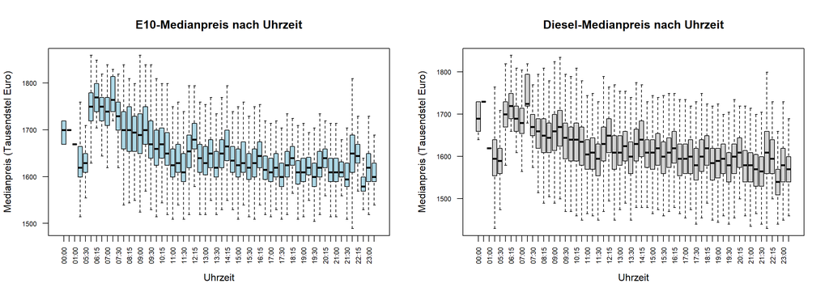

```r
# time als geordneten Faktor definieren
uhrzeiten <- sort(unique(tankerkoenig$time))
tankerkoenig$time_f <- factor(tankerkoenig$time, levels = uhrzeiten, ordered = TRUE)

par(mfrow = c(1, 2))

boxplot(e10_median ~ time_f, data = tankerkoenig,
        main = "E10-Medianpreis nach Uhrzeit",
        xlab = "Uhrzeit", ylab = "Medianpreis (Tausendstel Euro)",
        col = "lightblue", las = 2, cex.axis = 0.7,
        outline = FALSE)

boxplot(diesel_median ~ time_f, data = tankerkoenig,
        main = "Diesel-Medianpreis nach Uhrzeit",
        xlab = "Uhrzeit", ylab = "Medianpreis (Tausendstel Euro)",
        col = "lightgray", las = 2, cex.axis = 0.7,
        outline = FALSE)
```

```r
par(mfrow = c(1, 1))
```

```r
# Mediane pro Stunde für beide Kraftstoffe
uh_stats_e10   <- tapply(tankerkoenig$e10_median, tankerkoenig$time_f, median, na.rm = TRUE)
uh_stats_diesel <- tapply(tankerkoenig$diesel_median, tankerkoenig$time_f, median, na.rm = TRUE)

uh_vergleich <- data.frame(
  Uhrzeit = uhrzeiten,
  E10_Median = round(uh_stats_e10, 1),
  Diesel_Median = round(uh_stats_diesel, 1)
)

# Spanne (Maximum - Minimum) als Maß für den täglichen Schwankungsbereich
cat("E10   – Spanne über den Tag (Max–Min der stündl. Mediane):",
    round(max(uh_stats_e10, na.rm=TRUE) - min(uh_stats_e10, na.rm=TRUE), 1), "\n")
```

```
## E10   – Spanne über den Tag (Max–Min der stündl. Mediane): 190
```

```r
cat("Diesel – Spanne über den Tag (Max–Min der stündl. Mediane):",
    round(max(uh_stats_diesel, na.rm=TRUE) - min(uh_stats_diesel, na.rm=TRUE), 1), "\n")
```

```
## Diesel – Spanne über den Tag (Max–Min der stündl. Mediane): 190
```

```r
uh_vergleich
```

```
##       Uhrzeit E10_Median Diesel_Median
## 00:00   00:00       1699          1689
## 00:30   00:30       1699          1729
## 01:00   01:00       1669          1619
## 05:00   05:00       1619          1594
## 05:30   05:30       1629          1589
## 06:00   06:00       1749          1699
## 06:15   06:15       1769          1719
## 06:30   06:30       1749          1689
## 07:00   07:00       1739          1679
## 07:15   07:15       1764          1724
## 07:30   07:30       1729          1669
## 08:00   08:00       1699          1659
## 08:15   08:15       1699          1649
## 08:30   08:30       1694          1644
## 09:00   09:00       1689          1659
## 09:15   09:15       1699          1669
## 09:30   09:30       1669          1644
## 10:00   10:00       1659          1639
## 10:15   10:15       1669          1639
## 10:30   10:30       1649          1634
## 11:00   11:00       1624          1604
## 11:15   11:15       1629          1609
## 11:30   11:30       1609          1594
## 12:00   12:00       1654          1629
## 12:15   12:15       1679          1649
## 12:30   12:30       1639          1609
## 13:00   13:00       1629          1609
## 13:15   13:15       1649          1624
## 13:30   13:30       1619          1599
## 14:00   14:00       1649          1629
## 14:15   14:15       1664          1639
## 14:30   14:30       1634          1609
## 15:00   15:00       1624          1609
## 15:15   15:15       1629          1619
## 15:30   15:30       1619          1599
## 16:00   16:00       1629          1609
## 16:15   16:15       1644          1619
## 16:30   16:30       1614          1594
## 17:00   17:00       1609          1594
## 17:15   17:15       1619          1599
## 17:30   17:30       1599          1579
## 18:00   18:00       1624          1599
## 18:15   18:15       1639          1619
## 18:30   18:30       1609          1584
## 19:00   19:00       1609          1589
## 19:15   19:15       1619          1594
## 19:30   19:30       1599          1579
## 20:00   20:00       1619          1599
## 20:15   20:15       1639          1609
## 20:30   20:30       1609          1579
## 21:00   21:00       1609          1579
## 21:15   21:15       1609          1569
## 21:30   21:30       1594          1564
## 22:00   22:00       1649          1609
## 22:15   22:15       1644          1594
## 22:30   22:30       1579          1539
## 23:00   23:00       1619          1579
## 23:30   23:30       1599          1569
```

**c. Boxplots nach Marke**

Zuletzt schauen wir uns die Preise nach Marke an. Weil es viele verschiedene Marken gibt, sortieren wir sie nach ihrem E10-Median und drehen die Achsenbeschriftung, damit alles lesbar bleibt.

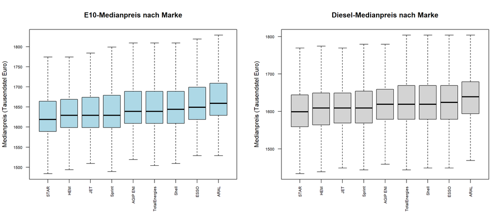

```r
# Marken nach medianem E10-Preis sortieren für bessere Lesbarkeit
marken_mediane_e10 <- tapply(tankerkoenig$e10_median, tankerkoenig$brand, median, na.rm = TRUE)
marken_order <- names(sort(marken_mediane_e10))

tankerkoenig$brand_f <- factor(tankerkoenig$brand, levels = marken_order)

par(mfrow = c(1, 2))

boxplot(e10_median ~ brand_f, data = tankerkoenig,
        main = "E10-Medianpreis nach Marke",
        xlab = "", ylab = "Medianpreis (Tausendstel Euro)",
        col = "lightblue", las = 2, cex.axis = 0.65,
        outline = FALSE)

boxplot(diesel_median ~ brand_f, data = tankerkoenig,
        main = "Diesel-Medianpreis nach Marke",
        xlab = "", ylab = "Medianpreis (Tausendstel Euro)",
        col = "lightgray", las = 2, cex.axis = 0.65,
        outline = FALSE)
```

```r
par(mfrow = c(1, 1))
```

```r
# Mediane pro Marke
mk_stats_e10    <- sort(tapply(tankerkoenig$e10_median, tankerkoenig$brand, median, na.rm = TRUE))
mk_stats_diesel <- tapply(tankerkoenig$diesel_median, tankerkoenig$brand, median, na.rm = TRUE)
mk_stats_diesel <- mk_stats_diesel[names(mk_stats_e10)]  # gleiche Reihenfolge

mk_vergleich <- data.frame(
  Marke = names(mk_stats_e10),
  E10_Median = round(mk_stats_e10, 1),
  Diesel_Median = round(mk_stats_diesel, 1)
)

cat("E10   – Spanne über Marken (teuerste − günstigste):",
    round(max(mk_stats_e10, na.rm=TRUE) - min(mk_stats_e10, na.rm=TRUE), 1), "\n")
```

```
## E10   – Spanne über Marken (teuerste − günstigste): 40
```

```r
cat("Diesel – Spanne über Marken (teuerste − günstigste):",
    round(max(mk_stats_diesel, na.rm=TRUE) - min(mk_stats_diesel, na.rm=TRUE), 1), "\n")
```

```
## Diesel – Spanne über Marken (teuerste − günstigste): 40
```

```r
mk_vergleich
```

```
##                       Marke E10_Median Diesel_Median
## STAR                   STAR       1619          1599
## HEM                     HEM       1629          1609
## JET                     JET       1629          1609
## Sprint               Sprint       1629          1609
## AGIP ENI           AGIP ENI       1639          1619
## TotalEnergies TotalEnergies       1639          1619
## Shell                 Shell       1644          1619
## ESSO                   ESSO       1649          1624
## ARAL                   ARAL       1659          1639
```

Die Unterschiede zwischen den Marken sind gut sichtbar. Große Markentankstellen wie Aral oder Shell verlangen tendenziell mehr, während JET und freie Tankstellen günstiger sind. Die Spanne zwischen der günstigsten und teuersten Marke ist bei beiden Kraftstoffen größer als die Schwankungen über die Wochentage.

**d. Stärkster Einflussfaktor auf die Kraftstoffpreise**

Um die drei Merkmale direkt vergleichen zu können, fassen wir die jeweiligen Spannen der Gruppen-Mediane in einer Tabelle zusammen.

```r
# Zusammenfassung der Spannen aller drei Merkmale
spanne_e10_wt     <- round(max(wt_stats_e10, na.rm=TRUE) - min(wt_stats_e10, na.rm=TRUE), 1)
spanne_e10_uh     <- round(max(uh_stats_e10, na.rm=TRUE) - min(uh_stats_e10, na.rm=TRUE), 1)
spanne_e10_mk     <- round(max(mk_stats_e10, na.rm=TRUE) - min(mk_stats_e10, na.rm=TRUE), 1)

spanne_diesel_wt  <- round(max(wt_stats_diesel, na.rm=TRUE) - min(wt_stats_diesel, na.rm=TRUE), 1)
spanne_diesel_uh  <- round(max(uh_stats_diesel, na.rm=TRUE) - min(uh_stats_diesel, na.rm=TRUE), 1)
spanne_diesel_mk  <- round(max(mk_stats_diesel, na.rm=TRUE) - min(mk_stats_diesel, na.rm=TRUE), 1)

vergleich_einfluss <- data.frame(
  Merkmal    = c("Wochentag", "Uhrzeit", "Marke"),
  E10_Spanne   = c(spanne_e10_wt, spanne_e10_uh, spanne_e10_mk),
  Diesel_Spanne = c(spanne_diesel_wt, spanne_diesel_uh, spanne_diesel_mk)
)
vergleich_einfluss
```

```
##     Merkmal E10_Spanne Diesel_Spanne
## 1 Wochentag          5            20
## 2   Uhrzeit        190           190
## 3     Marke         40            40
```

Den größten Einfluss auf die Kraftstoffpreise hat die **Uhrzeit**. Die Spanne der stündlichen Mediane ist bei E10 wie bei Diesel am größten und deutlich höher als bei den anderen beiden Merkmalen. Wer mittags tankt statt morgens, spart messbar – das zeigen die Boxplots sehr klar.

An zweiter Stelle steht die **Marke**. Auch hier sind die Preisunterschiede gut sichtbar und liegen deutlich über den Wochentags-Schwankungen. Je nach Marke kann man also ebenfalls einiges sparen.

Den geringsten Einfluss hat der **Wochentag**. Die Boxplots sehen von Montag bis Sonntag fast gleich aus, und die Spannen-Tabelle bestätigt das: Die Unterschiede zwischen den Tagen sind im Vergleich zu Uhrzeit und Marke vernachlässigbar.

## Quellen

[1] Tankerkönig UG, URL: https://tankerkoenig.de, letzter Aufruf: 27.04.2026